# INTERMEDIATE R: PACKAGES

R packages are bundles of code, data, documentation, and tests that are easy to share with others. For example, the `mean()`, `list()` and `sample()` functions are part of the **Base R** package, which contains the basic functionality to use R.

### 4.1 Install packages

Base R package is automatically installed and loaded. The package for data visualization, for example, has to be installed and loaded manually: `install.packages("ggvis")`. This goes to CRAN, download and install the package in your system.

### 4.2 Load packages

When R loads a package, it actually attaches it to the search list.

```r
search() # list of packages and environments that R looks through to find the variable or function you want to use.
```

```
## [1] ".GlobalEnv"        "package:stats"     "package:graphics"
## [4] "package:grDevices" "package:utils"     "package:datasets"
## [7] "package:methods"   "Autoloads"         "package:base"
```

*GlobalEnv* is the workspace where the user-defined R objects are stored.  
Try to access a function in the installed **ggvis** packages: `ggvis(mtcars, ~wt, ~hp)` returns an error, because **ggvis** is not yet in the search list.  
Load ggvis manually:

```r
library("ggvis")
```

Check once more:

```r
search() # ggvis is now a part of the list.
```

```
##  [1] ".GlobalEnv"        "package:ggvis"     "package:stats"
##  [4] "package:graphics"  "package:grDevices" "package:utils"
##  [7] "package:datasets"  "package:methods"   "Autoloads"
## [10] "package:base"
```

Run the ggvis function again:

```r
ggvis(mtcars, ~wt, ~hp) # print out a graph.
```

[output not shown]

```
## Guessing layer_points()
```

Another way to load packages is to use `require()` function for loading packages that are not yet installed.

```r
require("data.table") # return a warning if attaching package fails.
```

Check if the package is already attached:

```r
(result <- require("data.table"))
```

```
## [1] TRUE
```

This is a good alternative to avoid errors when attaching dynamically packages inside functions.

Load ggplot2 package:

```r
require("ggplot2")
```

Build a plot of two variables of the `mtcars` data frame using quick plot function from the package **ggplot2**

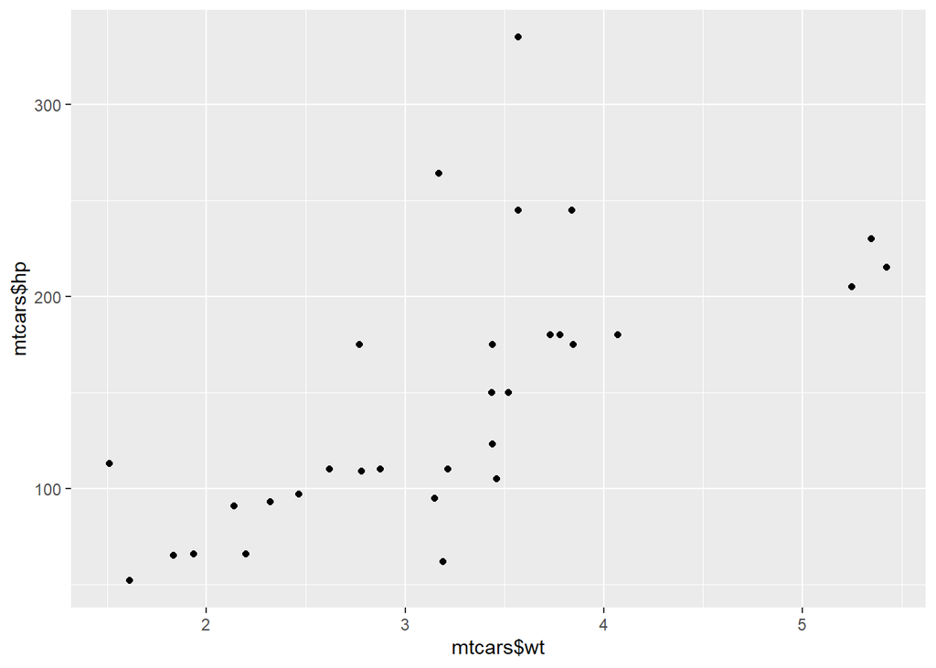

```r
qplot(mtcars$wt, mtcars$hp)
```